# InR PLS-DA analysis

Ming Yang

Compiled: September 28, 2021

In this R markdown file, I used a supervised method, Partial Least-Squares Discriminant Analysis (PLS-DA) implemented in the R package `mixOmics`, to perform sample classification, and then extracted metabolite features that are most informative of such classification.

# Dataset overview

**60 samples in total**

- 5 genotypes: wt, wt/353, 74/211, 211/19, 19/74
- 2 ages: 15d, 30d
- 3 batches: 1, 2, 3

2 replicates per genotype per age per batch

**The 5 genotypes can be grouped by insulin resistance**

- insulin sensitive: wt, wt/353
- insulin resistant: 19/74, 74/211, 211/19

**The 5 genotypes can be grouped by fecundity**

- normal fecundity: wt, 74/211, 211/19
- high fecundity: wt/353
- low fecundity: 19/74

```r
#BiocManager::install("mixOmics")
library(mixOmics)

# read in phenotype data
dat=readRDS('./mz.filter.dat.rds')
df.mat=dat$edata;
pheno=dat$pheno

# read in batch corrected data after `combat` function correction
df.res=readRDS('mz.filter.combat.rds')
#dim(df.res) #170 mz x 60 sample

# X: nsample x nfeature
X=t(df.res)
# Y: class
#insulin sensitive: wt, wt/353
#insulin resistant: 19/74, 74/211, 211/19
pheno$insulin=rep('resistant',nrow(pheno))
pheno[pheno$genotype %in% c('wt','wt/353'),]$insulin='sensitive'

#'normal' fecundity: wt, 74/211, 211/19
#high fecundity: wt/353
#low fecundity: 19/74
pheno$fecundity=rep('normal',nrow(pheno))
pheno[pheno$genotype=='wt/353',]$fecundity='high'
pheno[pheno$genotype=='19/74',]$fecundity='low'

table(pheno$genotype,pheno$insulin)
```

```
##
##          resistant sensitive
##   19/74         12         0
##   211/19        12         0
##   74/211        12         0
##   wt             0        12
##   wt/353         0        12
```

```r
table(pheno$genotype,pheno$fecundity)
```

```
##
##          high low normal
##   19/74     0  12      0
##   211/19    0   0     12
##   74/211    0   0     12
##   wt        0   0     12
##   wt/353   12   0      0
```

# Use PLS-DA to predict sample ‘insulin resistance’ label

Main steps:

- select #component: run 4-fold CV(cross validation) to select the optimal number of components
- select #metablite.feature: for each component, run 4-fold CV to select the optimal number of metabolite features
- extract those informative metabolite features

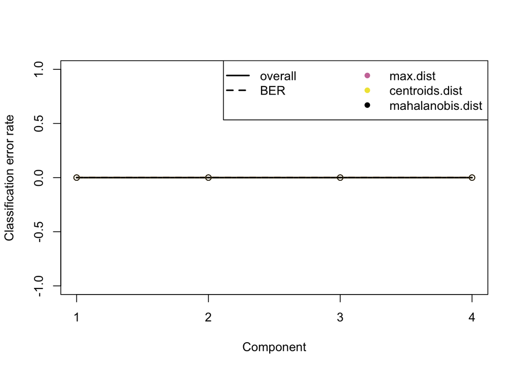

```r
## tune the model for insulin, two groups
Y=pheno$insulin
MyResult.plsda2 <- plsda(X,Y, ncomp=4)

# select ncomp
set.seed(30) # for reproducbility in this vignette, otherwise increase nrepeat
MyPerf.plsda <- perf(MyResult.plsda2,validation="Mfold", folds=4,
                     progressBar=FALSE, nrepeat=20) # we suggest nrepeat = 50
plot(MyPerf.plsda, col = color.mixo(5:7), sd = TRUE, legend.position = "horizontal")
```

```r
#MyPerf.plsda
```

The CER (classification error rate) is 0 with only one component, the data is super informative about insulin resistance status. I choose #component k = 2 to select #feature for each component.

```r
# for eacn comp, select n.feature
list.keepX <- c(5:10,  seq(20, 100, 10))
#list.keepX # to output the grid of values tested
set.seed(30) # for reproducbility in this vignette, otherwise increase nrepeat
tune.splsda.srbct <- tune.splsda(X, Y, ncomp = 2,
                                 validation = 'Mfold',
                                 folds = 4, dist = 'max.dist', progressBar = FALSE,
                                 measure = "BER", test.keepX = list.keepX,
                                 nrepeat = 20)
error <- tune.splsda.srbct$error.rate
#ncomp <- tune.splsda.srbct$choice.ncomp$ncomp # optimal number of components based on t-tests on the error rate
#ncomp
# 1
ncomp=2;
select.keepX <- tune.splsda.srbct$choice.keepX[1:ncomp]  # optimal number of variables to select
select.keepX
```

```
## comp1 comp2
##     5     5
```

```r
#plot(tune.splsda.srbct, col = color.jet(ncomp))
```

The best fitted model has #component k = 2, and #feature = 5 for each component, extract these metabolite features.

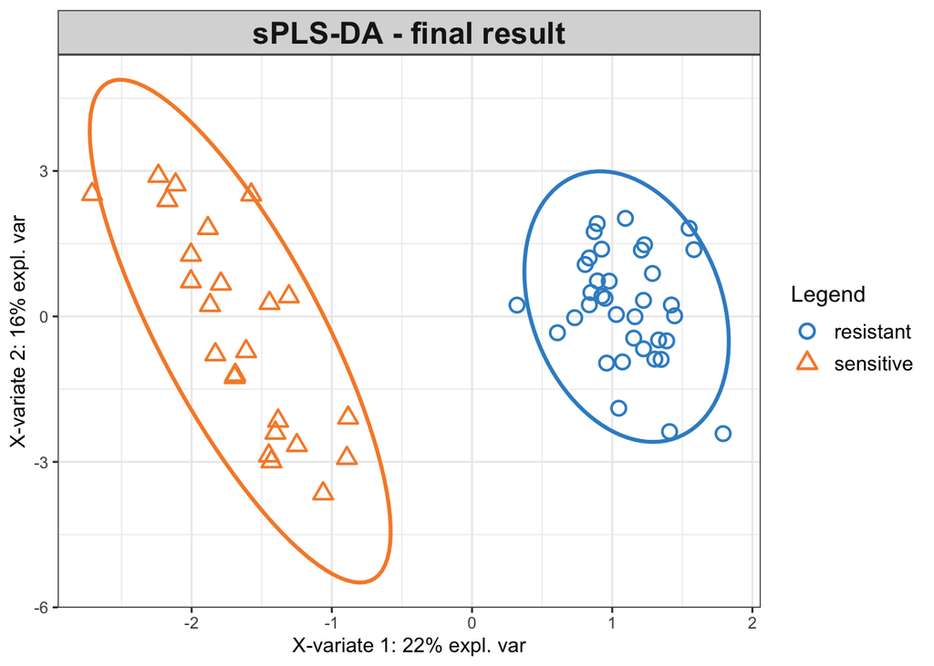

```r
#Based on those tuning results, run our final and tuned sPLS-DA model:
MyResult.splsda.final <- splsda(X, Y, ncomp = 2, keepX = select.keepX)
plotIndiv(MyResult.splsda.final, ind.names = FALSE, legend=TRUE,
          ellipse = TRUE, title="sPLS-DA - final result")
```

Visualize the metabolite feature contribution (loading) for component 1.

The height of each metabolite bar shows the contribution (loading).

The color of each metabolite bar shows the sample label for which the mean metabolite abundance is the maximum.

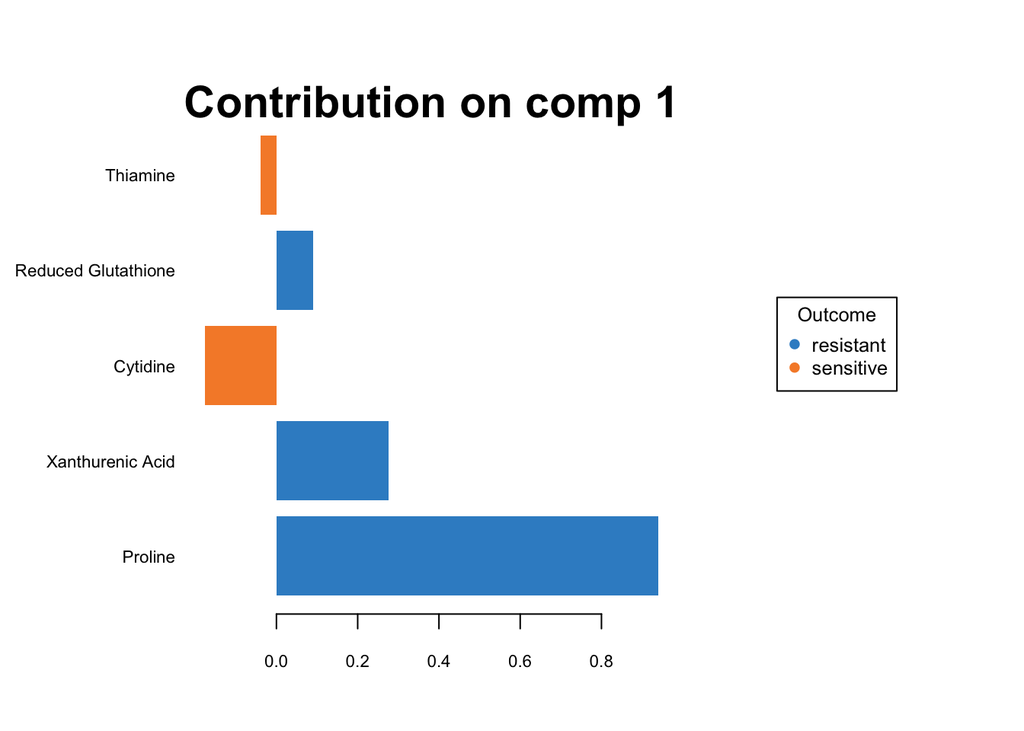

```r
#selectVar(MyResult.splsda.final,comp=1)$value
plotLoadings(MyResult.splsda.final,comp=1,contrib='max',method='mean')
```

# Use PLS-DA to predict sample ‘fecundity’ label

Main steps:

- select #component: run 4-fold CV(cross validation) to select the optimal number of components
- select #metablite.feature: for each component, run 4-fold CV to select the optimal number of metabolite features
- extract those informative metabolite features

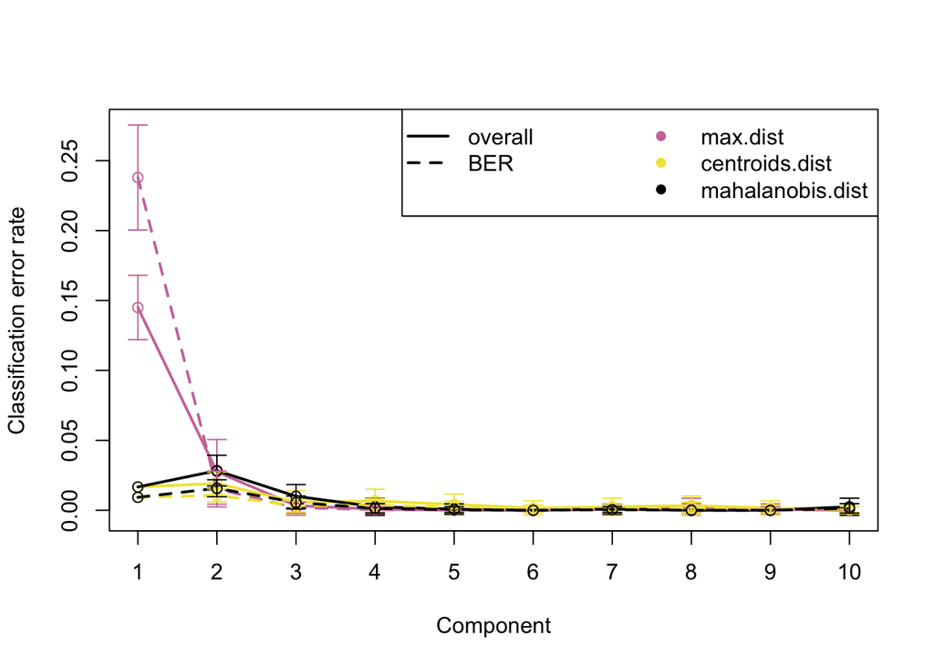

```r
## tune the model for fecundity
Y=pheno$fecundity
MyResult.plsda2 <- plsda(X,Y, ncomp=10)

# select ncomp
set.seed(30) # for reproducbility in this vignette, otherwise increase nrepeat
MyPerf.plsda <- perf(MyResult.plsda2, validation = "Mfold", folds = 4,
                     progressBar = FALSE, nrepeat = 20)

plot(MyPerf.plsda, col = color.mixo(5:7), sd = TRUE, legend.position = "horizontal")
```

```r
#MyPerf.plsda
```

The CER (classification error rate) is close 0 with 3 components. I choose #component k = 3 to select #feature for each component.

```r
# for eacn comp, select n.feature
list.keepX <- c(5:10,  seq(20, 100, 10))
#list.keepX # to output the grid of values tested
set.seed(30) # for reproducbility in this vignette, otherwise increase nrepeat
ncomp=3;
tune.splsda.srbct <- tune.splsda(X, Y, ncomp = ncomp,
                                 validation = 'Mfold',
                                 folds = 4, dist = 'max.dist', progressBar = FALSE,
                                 measure = "BER", test.keepX = list.keepX,
                                 nrepeat = 20)
error <- tune.splsda.srbct$error.rate
#ncomp <- tune.splsda.srbct$choice.ncomp$ncomp # optimal number of components based on t-tests on the error rate
#ncomp

select.keepX <- tune.splsda.srbct$choice.keepX[1:ncomp]  # optimal number of variables to select
select.keepX
```

```
## comp1 comp2 comp3
##    20    30   100
```

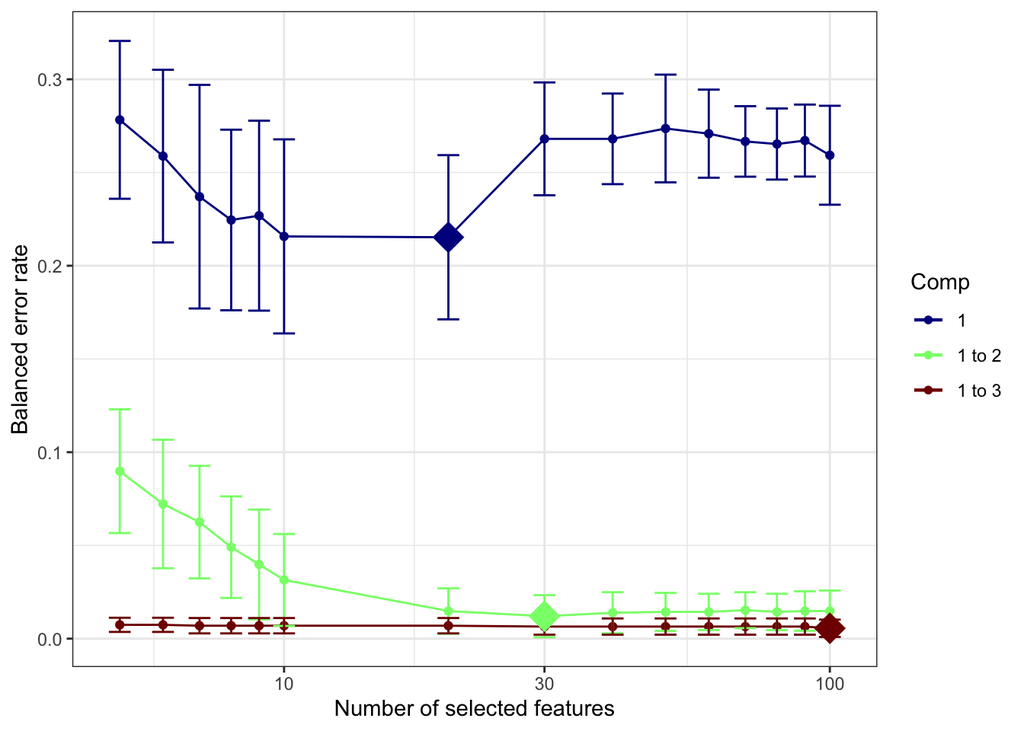

```r
plot(tune.splsda.srbct, col = color.jet(ncomp))
```

The best fitted model has #component k = 3, and #feature = 20, 30, 100 for component 1,2,3, respectively.

Extract these metabolite features.

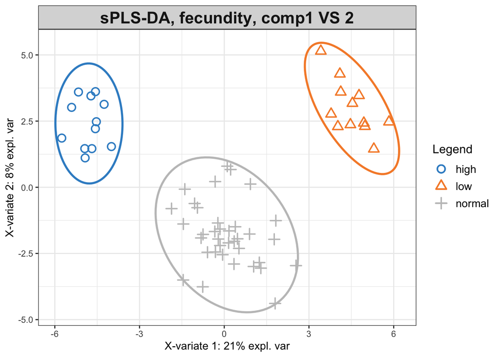

```r
#Based on those tuning results, we can run our final and tuned sPLS-DA model:
MyResult.splsda.final <- splsda(X, Y, ncomp = 3, keepX = select.keepX)

plotIndiv(MyResult.splsda.final, ind.names = FALSE, legend=TRUE, ellipse = TRUE, title="sPLS-DA, fecundity, comp1 VS 2")
```

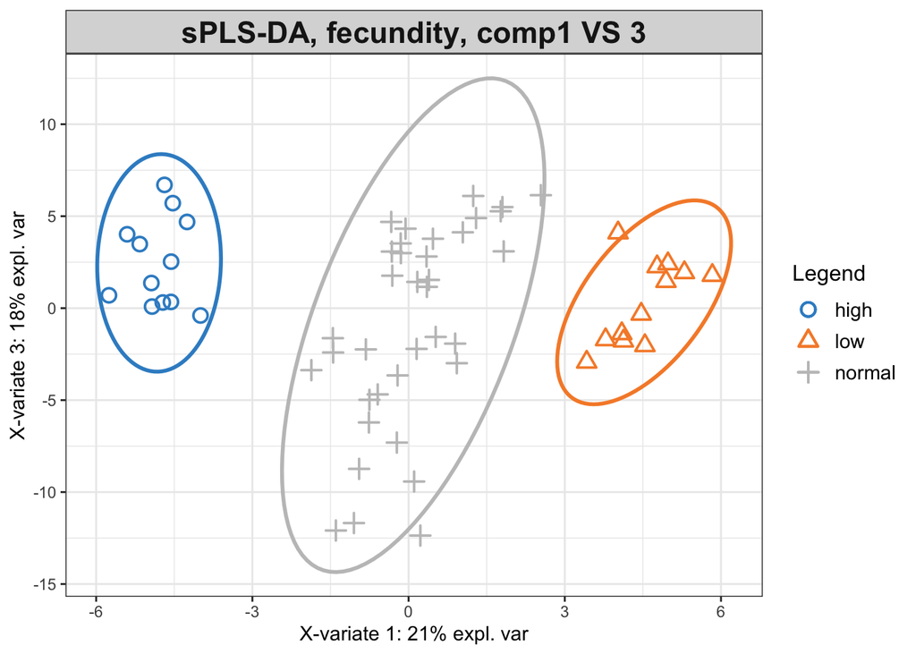

```r
plotIndiv(MyResult.splsda.final,comp=c(1,3), ind.names = FALSE, legend=TRUE, ellipse = TRUE, title="sPLS-DA, fecundity, comp1 VS 3")
```

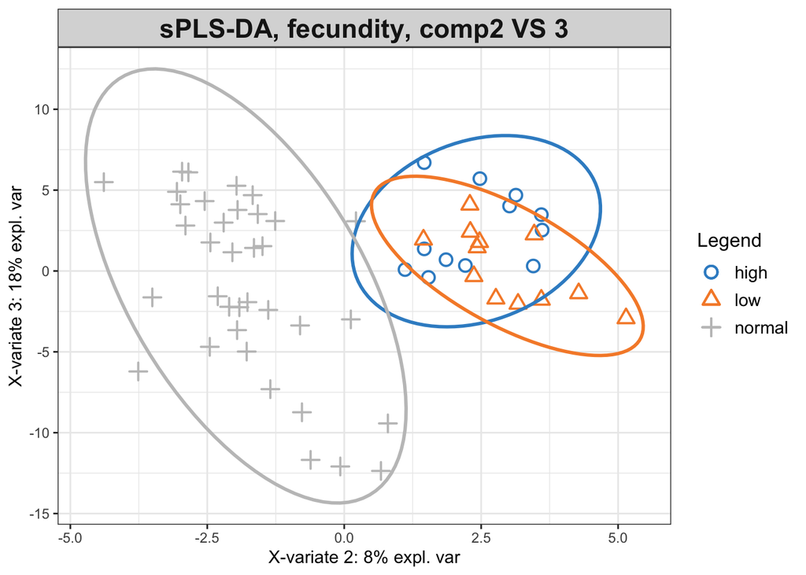

```r
plotIndiv(MyResult.splsda.final,comp=c(2,3), ind.names = FALSE, legend=TRUE, ellipse = TRUE, title="sPLS-DA, fecundity, comp2 VS 3")
```

Based on the plots, component 1 is already very informative about sample classification.

Below are the selected metabolite features for component 1 and 2.

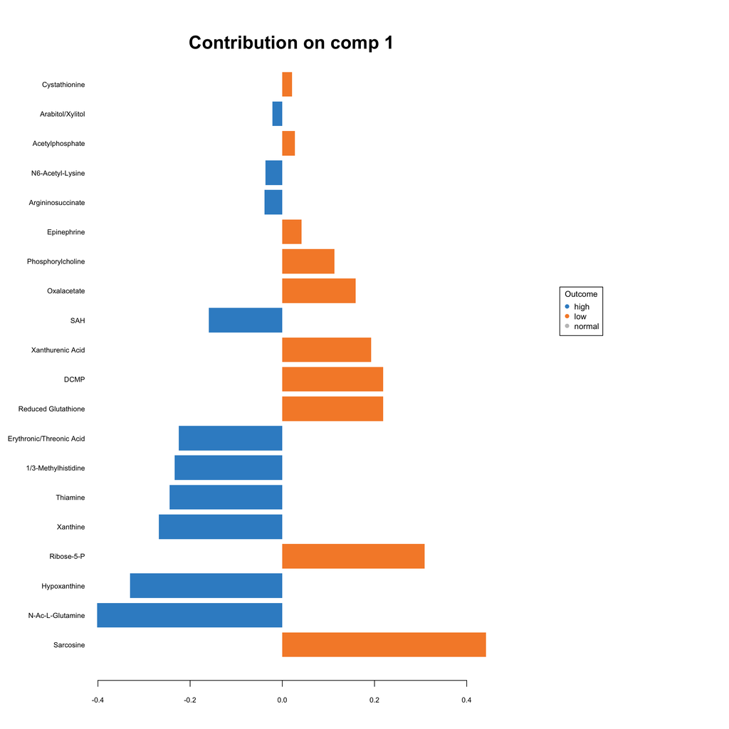

```r
plotLoadings(MyResult.splsda.final,comp=1,contrib='max',method='mean')
```

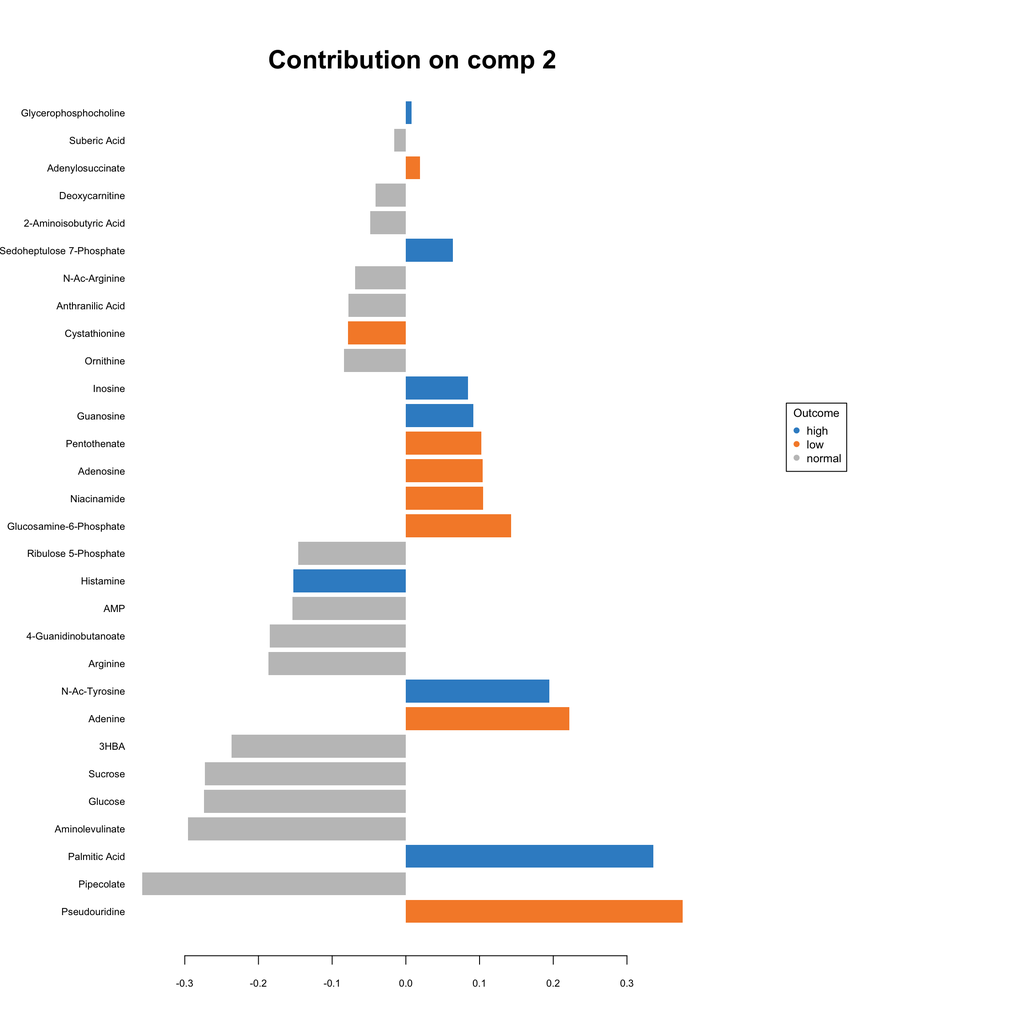

```r
plotLoadings(MyResult.splsda.final,comp=2,contrib='max',method='mean')
```

```r
#plotLoadings(MyResult.splsda.final,comp=3,contrib='max',method='mean')

selectVar(MyResult.splsda.final,comp=1)$value
```

```
##                            value.var
## Sarcosine                 0.44184290
## N-Ac-L-Glutamine         -0.40153414
## Hypoxanthine             -0.33060373
## Ribose-5-P                0.30847215
## Xanthine                 -0.26815282
## Thiamine                 -0.24418001
## 1/3-Methylhistidine      -0.23350897
## Erythronic/Threonic Acid -0.22434328
## Reduced Glutathione       0.21907536
## DCMP                      0.21865812
## Xanthurenic Acid          0.19242183
## SAH                      -0.15968156
## Oxalacetate               0.15924542
## Phosphorylcholine         0.11301113
## Epinephrine               0.04190273
## Argininosuccinate        -0.03879659
## N6-Acetyl-Lysine         -0.03667877
## Acetylphosphate           0.02703718
## Arabitol/Xylitol         -0.02139734
## Cystathionine             0.02120307
```

```r
selectVar(MyResult.splsda.final,comp=2)$value
```

```
##                              value.var
## Pseudouridine              0.375593355
## Pipecolate                -0.357723853
## Palmitic Acid              0.335625750
## Aminolevulinate           -0.295437818
## Glucose                   -0.274044538
## Sucrose                   -0.272916643
## 3HBA                      -0.236685283
## Adenine                    0.221998071
## N-Ac-Tyrosine              0.194514022
## Arginine                  -0.186288186
## 4-Guanidinobutanoate      -0.184747321
## AMP                       -0.154166181
## Histamine                 -0.152476218
## Ribulose 5-Phosphate      -0.145930873
## Glucosamine-6-Phosphate    0.142708357
## Niacinamide                0.105055548
## Adenosine                  0.104441284
## Pentothenate               0.102303748
## Guanosine                  0.091687102
## Inosine                    0.084333211
## Ornithine                 -0.084223327
## Cystathionine             -0.078794626
## Anthranilic Acid          -0.077862052
## N-Ac-Arginine             -0.068941741
## Sedoheptulose 7-Phosphate  0.063896737
## 2-Aminoisobutyric Acid    -0.048246837
## Deoxycarnitine            -0.040865417
## Adenylosuccinate           0.019245202
## Suberic Acid              -0.015638946
## Glycerophosphocholine      0.007580034
```

```r
#selectVar(MyResult.splsda.final,comp=3)$value
```

```r
installed.packages()[names(sessionInfo()$otherPkgs), "Version"]
```

```
##  mixOmics   ggplot2   lattice      MASS
##  "6.16.0"   "3.3.5" "0.20-44"  "7.3-54"
```